Tarea 5 - Relaciones entre Variables Cualitativas

Por: César Omar López Arteaga

Marzo 2024

# Pregunta 1

Bajar el archivo Fiebre en R. Calcular las incidencias de la presencia de cada carácter, la razón de riesgos de ambos, y la razón de momias.

Primero, necesitas instalar y cargar la biblioteca rio, lo cual se hace con los siguientess comandos:

```r
# Instalar la biblioteca rio si aún no está instalada
install.packages("rio",repos = "https://cloud.r-project.org/")
```

```r
# Cargar la biblioteca rio
library(rio)
```

Se descargara el archivo Fiebre.csv a una carpeta local, luego se cargara el archivo y se muestrara la estructura de la data, luego se muestra la tabla

```r
# Leer datos desde un archivo CSV
tab <- import("G:/R IMCA/TAREA 5/DESCARGA_DATA/Fiebre.csv")
#Impresion de la tabla
print(tab)
```

```
##          V1 Fiebre de heno No fiebre Total
## 1    Eccema            141       420   561
## 2 No eccema            928     13525 14453
## 3     Total           1069     13945 15014
```

```r
#Calculo de Incidencia de presencia
tab[1,2]<-tab[1,2]/tab[3,4]
tab[1,3]<-tab[1,3]/tab[3,4]
tab[1,4]<-tab[1,4]/tab[3,4]

tab[2,2]<-tab[2,2]/tab[3,4]
tab[2,3]<-tab[2,3]/tab[3,4]
tab[2,4]<-tab[2,4]/tab[3,4]

tab[3,2]<-tab[3,2]/tab[3,4]
tab[3,3]<-tab[3,3]/tab[3,4]
tab[3,4]<-tab[3,4]/tab[3,4]

#Tabla de Incidencia de presencia
print("Tabla de Incendencia")
print(tab)
```

```
## [1] "Tabla de Incendencia"
##          V1 Fiebre de heno  No fiebre      Total
## 1    Eccema    0.009391235 0.02797389 0.03736513
## 2 No eccema    0.061808978 0.90082590 0.96263487
## 3     Total    0.071200213 0.92879979 1.00000000
```

```r
# Calculo de razon de riesgo
V1_P <- tab[1,2]/tab[1,4]
V1_A <- tab[2,2]/tab[2,4]
RR_V1_V2<-V1_P/V1_A
cat("RR(V1|V2) = ",round(RR_V1_V2,7),"\n")

V2_P <- tab[1,2]/tab[3,2]
V2_A <- tab[1,3]/tab[3,3]
RR_V2_V1<-V2_P/V2_A
cat("RR(V2|V1) = ",round(RR_V2_V1,7),"\n")
```

```
## RR(V1|V2) =  3.91441
## RR(V2|V1) =  4.37936
```

```r
# Calculo de razon de momios (odds ratio)
RM_V1_V2<-(tab[1,2]/tab[1,3])/(tab[2,2]/tab[2,3])
cat("RM(V1|V2) =",round(RM_V1_V2,7),"\n")
```

```
## RM(V1|V2) = 4.892819
```

```r
RM_V2_V1<-(tab[1,2]/tab[2,2])/(tab[1,3]/tab[2,3])
cat("RM(V2|V1) =",round(RM_V2_V1,7),"\n")
```

```
## RM(V2|V1) = 4.892819
```

# Pregunta 2

Bajar el archivo Suicidios: son chicos que tentaron el suicidio y seis meses después todavía tienen un comportamiento suicida o no, con o sin depresión. Calcular las incidencias, las razones de riesgo y la razón de momias.

Se descargara el archivo Suicidas.csv a una carpeta local, luego se cargara el archivo y se muestrara la estructura de la data, luego se muestra la tabla

```r
# Leer datos desde un archivo CSV
tab <- import("G:/R IMCA/TAREA 5/DESCARGA_DATA/Suicidas.csv")
#Impresion de la tabla
print(tab)
```

```
##                       V1 Depresion No_Depresion Total
## 1 Comportamiento_suicida        86          100   186
## 2             No suicida        45           32    77
## 3                  Total       131          132   263
```

```r
#Calculo de Incidencia de presencia
tab[1,2]<-tab[1,2]/tab[3,4]
tab[1,3]<-tab[1,3]/tab[3,4]
tab[1,4]<-tab[1,4]/tab[3,4]

tab[2,2]<-tab[2,2]/tab[3,4]
tab[2,3]<-tab[2,3]/tab[3,4]
tab[2,4]<-tab[2,4]/tab[3,4]

tab[3,2]<-tab[3,2]/tab[3,4]
tab[3,3]<-tab[3,3]/tab[3,4]
tab[3,4]<-tab[3,4]/tab[3,4]

#Tabla de Incidencia de presencia
print("Tabla de Incendencia")
print(tab)
```

```
## [1] "Tabla de Incendencia"
##                       V1 Depresion No_Depresion     Total
## 1 Comportamiento_suicida 0.3269962    0.3802281 0.7072243
## 2             No suicida 0.1711027    0.1216730 0.2927757
## 3                  Total 0.4980989    0.5019011 1.0000000
```

```r
# Calculo de razon de riesgo
V1_P <- tab[1,2]/tab[1,4]
V1_A <- tab[2,2]/tab[2,4]
RR_V1_V2<-V1_P/V1_A
cat("RR(V1|V2) = ",round(RR_V1_V2,7),"\n")

V2_P <- tab[1,2]/tab[3,2]
V2_A <- tab[1,3]/tab[3,3]
RR_V2_V1<-V2_P/V2_A
cat("RR(V2|V1) = ",round(RR_V2_V1,7),"\n")
```

```
## RR(V1|V2) =  0.7911589
## RR(V2|V1) =  0.8665649
```

```r
# Calculo de razon de momios (odds ratio)
RM_V1_V2<-(tab[1,2]/tab[1,3])/(tab[2,2]/tab[2,3])
cat("RM(V1|V2) =",round(RM_V1_V2,7),"\n")
```

```
## RM(V1|V2) = 0.6115556
```

```r
RM_V2_V1<-(tab[1,2]/tab[2,2])/(tab[1,3]/tab[2,3])
cat("RM(V2|V1) =",round(RM_V2_V1,7),"\n")
```

```
## RM(V2|V1) = 0.6115556
```

# Pregunta 3

Bajar el archivo Hongos.csv: son frecuencias de hongos en presencia/ausencia de árboles de abedul o abeto. Calcular las incidencias de hongo las razones de riesgo y de momios, considerando la presencia de una planta como la ausencia de otra

Se descargara el archivo Hongos.csv a una carpeta local, luego se cargara el archivo y se muestrara la estructura de la data, luego se muestra la tabla

```r
# Leer datos desde un archivo CSV
tab <- import("G:/R IMCA/TAREA 5/DESCARGA_DATA/Hongos.csv")
tab[1,4]<-tab[1,2]+tab[1,3]
tab[2,4]<-tab[2,2]+tab[2,3]

tab[3,2]<-tab[1,2]+tab[2,2]
tab[3,3]<-tab[1,3]+tab[2,3]

tab[3,4]<-tab[3,2]+tab[3,3]
#Impresion de la tabla
print(tab)
```

```
##          V1 abedul abedo   V4
## 1    Hongos     14    50   64
## 2 No_Hongos    126   950 1076
## 3      <NA>    140  1000 1140
```

```r
#Calculo de Incidencia de presencia
tab[1,2]<-tab[1,2]/tab[3,4]
tab[1,3]<-tab[1,3]/tab[3,4]
tab[1,4]<-tab[1,4]/tab[3,4]

tab[2,2]<-tab[2,2]/tab[3,4]
tab[2,3]<-tab[2,3]/tab[3,4]
tab[2,4]<-tab[2,4]/tab[3,4]

tab[3,2]<-tab[3,2]/tab[3,4]
tab[3,3]<-tab[3,3]/tab[3,4]
tab[3,4]<-tab[3,4]/tab[3,4]

#Tabla de Incidencia de presencia
print("Tabla de Incendencia")
print(tab)
```

```
## [1] "Tabla de Incendencia"
##          V1    abedul      abedo         V4
## 1    Hongos 0.0122807 0.04385965 0.05614035
## 2 No_Hongos 0.1105263 0.83333333 0.94385965
## 3      <NA> 0.1228070 0.87719298 1.00000000
```

```r
# Calculo de razon de riesgo
V1_P <- tab[1,2]/tab[1,4]
V1_A <- tab[2,2]/tab[2,4]
RR_V1_V2<-V1_P/V1_A
cat("RR(V1|V2) = ",round(RR_V1_V2,7),"\n")

V2_P <- tab[1,2]/tab[3,2]
V2_A <- tab[1,3]/tab[3,3]
RR_V2_V1<-V2_P/V2_A
cat("RR(V2|V1) = ",round(RR_V2_V1,7),"\n")
```

```
## RR(V1|V2) =  1.868056
## RR(V2|V1) =  2
```

```r
# Calculo de razon de momios (odds ratio)
RM_V1_V2<-(tab[1,2]/tab[1,3])/(tab[2,2]/tab[2,3])
cat("RM(V1|V2) =",round(RM_V1_V2,7),"\n")
```

```
## RM(V1|V2) = 2.111111
```

```r
RM_V2_V1<-(tab[1,2]/tab[2,2])/(tab[1,3]/tab[2,3])
cat("RM(V2|V1) =",round(RM_V2_V1,7),"\n")
```

```
## RM(V2|V1) = 2.111111
```

# Pregunta 4

# Pregunta 5

Bajar el archivo Ellenberg.csv: son presencias de 76 especies de hierbas en 25 sitios.

Se descargara el archivo Ellenberg.csv a una carpeta local, luego se cargara el archivo y se muestrara la estructura de la data, luego se muestra la tabla

```r
# Carga de la data Iris
tab<- read.csv("G:/R IMCA/TAREA 5/DESCARGA_DATA/Ellenberg.csv",header=TRUE,row.names=1)

# Verificar la estructura de los datos
str(tab)
```

```
## 'data.frame':    76 obs. of  25 variables:
##  $ X1 : int  0 1 0 1 1 1 1 1 1 0 ...
##  $ X2 : int  1 1 1 0 1 1 1 0 0 1 ...
##  $ X3 : int  0 1 0 1 0 1 0 0 0 1 ...
##  $ X4 : int  1 1 0 1 0 1 0 1 1 0 ...
##  $ X5 : int  1 1 1 0 0 1 0 0 1 1 ...
##  $ X6 : int  1 1 1 0 0 1 0 0 0 1 ...
##  $ X7 : int  1 1 1 0 0 1 0 0 0 1 ...
##  $ X8 : int  1 1 0 0 0 1 0 0 1 1 ...
##  $ X9 : int  1 1 1 1 1 1 1 1 1 1 ...
##  $ X10: int  1 1 1 1 1 1 1 1 1 1 ...
##  $ X11: int  1 1 0 0 0 1 0 0 1 1 ...
##  $ X12: int  1 1 1 0 0 1 0 0 1 1 ...
##  $ X13: int  1 1 1 0 0 1 0 0 1 1 ...
##  $ X14: int  1 1 0 0 0 1 0 0 0 1 ...
##  $ X15: int  1 1 0 1 0 1 0 0 1 1 ...
##  $ X16: int  1 1 1 0 0 1 1 0 0 1 ...
##  $ X17: int  1 1 1 0 0 1 0 0 1 1 ...
##  $ X18: int  1 1 1 0 0 1 0 0 0 1 ...
##  $ X19: int  1 1 0 0 0 1 0 0 1 1 ...
##  $ X20: int  1 1 1 0 0 1 0 0 1 1 ...
##  $ X21: int  1 1 1 0 0 1 0 0 0 1 ...
##  $ X22: int  1 1 1 0 0 1 0 0 0 1 ...
##  $ X23: int  1 1 0 0 0 1 0 0 1 1 ...
##  $ X24: int  1 1 1 1 0 1 0 0 1 1 ...
##  $ X25: int  1 1 0 0 0 1 0 0 0 1 ...
```

```r
# Visualizar los primeros registros de los datos sin modificar
head(tab,n=10)
```

|  | X1 | X2 | X3 | X4 | X5 | X6 | X7 | X8 | X9 | X10 | X11 | X12 | X13 | X14 | X15 | X16 | X17 | X18 | X19 | X20 | X21 | X22 | X23 | X24 | X25 |
| --- | --- | --- | --- | --- | --- | --- | --- | --- | --- | --- | --- | --- | --- | --- | --- | --- | --- | --- | --- | --- | --- | --- | --- | --- | --- |
| Arre_elat | 0 | 1 | 0 | 1 | 1 | 1 | 1 | 1 | 1 | 1 | 1 | 1 | 1 | 1 | 1 | 1 | 1 | 1 | 1 | 1 | 1 | 1 | 1 | 1 | 1 |
| Dact_glom | 1 | 1 | 1 | 1 | 1 | 1 | 1 | 1 | 1 | 1 | 1 | 1 | 1 | 1 | 1 | 1 | 1 | 1 | 1 | 1 | 1 | 1 | 1 | 1 | 1 |
| Heli_pube | 0 | 1 | 0 | 0 | 1 | 1 | 1 | 0 | 1 | 1 | 0 | 1 | 1 | 0 | 0 | 1 | 1 | 1 | 0 | 1 | 1 | 1 | 0 | 1 | 0 |
| Brom_erec | 1 | 0 | 1 | 1 | 0 | 0 | 0 | 0 | 1 | 1 | 0 | 0 | 0 | 0 | 1 | 0 | 0 | 0 | 0 | 0 | 0 | 0 | 0 | 1 | 0 |
| Fest_ovin | 1 | 1 | 0 | 0 | 0 | 0 | 0 | 0 | 1 | 1 | 0 | 0 | 0 | 0 | 0 | 0 | 0 | 0 | 0 | 0 | 0 | 0 | 0 | 0 | 0 |
| Poa_prat | 1 | 1 | 1 | 1 | 1 | 1 | 1 | 1 | 1 | 1 | 1 | 1 | 1 | 1 | 1 | 1 | 1 | 1 | 1 | 1 | 1 | 1 | 1 | 1 | 1 |
| Briz_medi | 1 | 1 | 0 | 0 | 0 | 0 | 0 | 0 | 1 | 1 | 0 | 0 | 0 | 0 | 0 | 1 | 0 | 0 | 0 | 0 | 0 | 0 | 0 | 0 | 0 |
| Koel_pyra | 1 | 0 | 0 | 1 | 0 | 0 | 0 | 0 | 1 | 1 | 0 | 0 | 0 | 0 | 0 | 0 | 0 | 0 | 0 | 0 | 0 | 0 | 0 | 0 | 0 |
| Fest_rubr | 1 | 0 | 0 | 1 | 1 | 0 | 0 | 1 | 1 | 1 | 1 | 1 | 1 | 0 | 1 | 0 | 1 | 0 | 1 | 1 | 0 | 0 | 1 | 1 | 0 |
| Fest_prat | 0 | 1 | 1 | 0 | 1 | 1 | 1 | 1 | 1 | 1 | 1 | 1 | 1 | 1 | 1 | 1 | 1 | 1 | 1 | 1 | 1 | 1 | 1 | 1 | 1 |

De la exploracion de datos del rachivo Ellenberg, se observa que las variables son cualitativas. Hay 25 variables cualitativa de sitio contra 76 varibales cualitativa de tipos de observaciones de la planta que hay en una zona.El llenado de esta tabla indica si una especie esta o no presenta en una localidad. SI esta presente se le da el valor de 1 y si no esta presente el valor de 0.

# Pregunta 6

Calcular los índices de Van der Maarel y de Sørensen sobre la tabla, tanto entre sitios como entre especies.

Para el calculo de los indices de Van de Maarel y Sørensen, supondremos que las variable de interes seran las variables observadas(tipo de planta), por lo cual se hara una tabla cruzada llamada “df”, el cual solo interesara si una especie con respecto a la otra esta presente.

```r
#Numero de varibles de sitios
n<-ncol(tab)

#Numero de varibles de especies
m<-nrow(tab)

#Inicializcion del dataframe de la tabla cruzada en ceros
df<-as.data.frame(matrix(0,nrow = m,  ncol=m))
rownames(df)<-rownames(tab)
colnames(df)<-rownames(tab)

#Llenado del dataframe, segun las visualizaciones tenidas
for (i in 1:m){
  for (j in i:m){
    if (i==j){
      df[i,j]=1
    }else{
      xx<-sum((tab[i,]==tab[j,])&!(tab[i,]==0))
      df[i,j]=xx
      df[j,i]=xx
    }
  }
}
# Verificar la estructura de los datos
str(df)
```

```
## 'data.frame':    76 obs. of  76 variables:
##  $ Arre_elat: num  1 23 15 5 3 23 4 3 14 22 ...
##  $ Dact_glom: num  23 1 15 7 4 25 5 4 15 23 ...
##  $ Heli_pube: num  15 15 1 3 3 15 4 2 8 15 ...
##  $ Brom_erec: num  5 7 3 1 3 7 3 4 6 5 ...
##  $ Fest_ovin: num  3 4 3 3 1 4 4 3 3 3 ...
##  $ Poa_prat : num  23 25 15 7 4 1 5 4 15 23 ...
##  $ Briz_medi: num  4 5 4 3 4 5 1 3 3 4 ...
##  $ Koel_pyra: num  3 4 2 4 3 4 3 1 4 2 ...
##  $ Fest_rubr: num  14 15 8 6 3 15 3 4 1 13 ...
##  $ Fest_prat: num  22 23 15 5 3 23 4 2 13 1 ...
##  $ Tris_flav: num  14 15 11 4 2 15 3 1 9 15 ...
##  $ Alop_prat: num  9 9 6 0 0 9 0 0 4 9 ...
##  $ Holo_lana: num  12 12 6 0 0 12 0 0 7 12 ...
##  $ Desc_caes: num  7 7 3 0 0 7 0 0 4 7 ...
```

[output cut: 62 more lines]

```r
# Visualizar los primeros registros de los datos de la tabla cruzada
head(df,n=25)
```

|  | Arre_elat | Dact_glom | Heli_pube | Brom_erec | Fest_ovin | Poa_prat | Briz_medi | Koel_pyra | Fest_rubr | Fest_prat | Tris_flav | Alop_prat | Holo_lana | Desc_caes | Care_flac | Care_acut | Care_hirt | Care_grac | Trif_prat | Trif_repe | Medi_lupu | Vici_sepi | Lotu_corn | Lath_prat | Vici_crac | Achi_mill | Dauc_caro | Camp_rotu | Plan_lanc | … |
| --- | --- | --- | --- | --- | --- | --- | --- | --- | --- | --- | --- | --- | --- | --- | --- | --- | --- | --- | --- | --- | --- | --- | --- | --- | --- | --- | --- | --- | --- | --- |
| Arre_elat | 1 | 23 | 15 | 5 | 3 | 23 | 4 | 3 | 14 | 22 | 14 | 9 | 12 | 7 | 5 | 5 | 2 | 2 | 15 | 13 | 15 | 6 | 3 | 10 | 5 | 19 | 18 | 11 | 23 | … |
| Dact_glom | 23 | 1 | 15 | 7 | 4 | 25 | 5 | 4 | 15 | 23 | 15 | 9 | 12 | 7 | 6 | 5 | 2 | 2 | 17 | 14 | 17 | 7 | 4 | 10 | 5 | 21 | 20 | 13 | 25 | … |
| Heli_pube | 15 | 15 | 1 | 3 | 3 | 15 | 4 | 2 | 8 | 15 | 11 | 6 | 6 | 3 | 2 | 2 | 1 | 0 | 11 | 8 | 10 | 4 | 1 | 7 | 3 | 14 | 14 | 5 | 15 | … |
| Brom_erec | 5 | 7 | 3 | 1 | 3 | 7 | 3 | 4 | 6 | 5 | 4 | 0 | 0 | 0 | 3 | 0 | 0 | 0 | 5 | 3 | 6 | 4 | 2 | 1 | 3 | 7 | 6 | 7 | 7 | … |
| Fest_ovin | 3 | 4 | 3 | 3 | 1 | 4 | 4 | 3 | 3 | 3 | 2 | 0 | 0 | 0 | 1 | 0 | 0 | 0 | 2 | 2 | 3 | 1 | 0 | 1 | 1 | 4 | 4 | 3 | 4 | … |
| Poa_prat | 23 | 25 | 15 | 7 | 4 | 1 | 5 | 4 | 15 | 23 | 15 | 9 | 12 | 7 | 6 | 5 | 2 | 2 | 17 | 14 | 17 | 7 | 4 | 10 | 5 | 21 | 20 | 13 | 25 | … |
| Briz_medi | 4 | 5 | 4 | 3 | 4 | 5 | 1 | 3 | 3 | 4 | 3 | 0 | 0 | 0 | 2 | 0 | 0 | 0 | 3 | 3 | 4 | 1 | 0 | 1 | 2 | 5 | 5 | 4 | 5 | … |
| Koel_pyra | 3 | 4 | 2 | 4 | 3 | 4 | 3 | 1 | 4 | 2 | 1 | 0 | 0 | 0 | 2 | 0 | 0 | 0 | 2 | 2 | 4 | 2 | 0 | 1 | 1 | 4 | 4 | 4 | 4 | … |
| Fest_rubr | 14 | 15 | 8 | 6 | 3 | 15 | 3 | 4 | 1 | 13 | 9 | 4 | 7 | 4 | 4 | 2 | 2 | 1 | 9 | 8 | 11 | 4 | 2 | 7 | 3 | 12 | 12 | 9 | 15 | … |
| Fest_prat | 22 | 23 | 15 | 5 | 3 | 23 | 4 | 2 | 13 | 1 | 15 | 9 | 12 | 7 | 4 | 5 | 2 | 2 | 15 | 13 | 15 | 6 | 4 | 10 | 5 | 19 | 18 | 11 | 23 | … |

[output cut: 15 more lines]

Para el calculo de los indices de Sørensen y Van de Maarel, de la tabla cruzada se analiza cada entrada de esta tabla(df) y se construira unas subtabla de contigencia, el cual se podra calculas cada uno de los indices, este calaculo se guardara en las nueva tablas “SOR” para el indice de Sørensen y en la tabla “VAN” para el indice de Van de Maarel.

```r
# DEFINICIONES DE FUNCIONES PARA CALCULO DE INDICES
# Indice de Sorenso
ind_sor<-function(a,b,c){
  return(2*a/(2*a+b+c))
}

# Indice de Van de Maarel
ind_van<-function(a,b,c){
  return((2*a-(b+c))/(2*a+b+c))
}
```

```r
# CALCULO DE INDICES
#Numero de varibles de sitios
n<-ncol(tab)

#Numero de varibles de especies
m<-nrow(tab)

#Inicializcion del dataframe de la tabla para los indices SOR con ceros
SOR<-as.data.frame(matrix(0,nrow = m,  ncol=m))
rownames(SOR)<-rownames(tab)
colnames(SOR)<-rownames(tab)

#Inicializcion del dataframe de la tabla para los indices VAN con ceros
VAN<-as.data.frame(matrix(0,nrow = m,  ncol=m))
rownames(VAN)<-rownames(tab)
colnames(VAN)<-rownames(tab)

#Llenado del dataframe SOR, segun las visualizaciones tenidas
for (i in 1:m){
  for (j in i:m){
    if (i==j){
      SOR[i,j]=1
      VAN[i,j]=1
    }else{
      a<-df[i,j]
      c<-sum(df[i,])-1-df[i,j]
      b<-sum(df[,j])-1-df[i,j]

      xx<-ind_sor(a,b,c)
      SOR[i,j]=xx
      SOR[j,i]=xx

      yy<-ind_van(a,b,c)
      VAN[i,j]=yy
      VAN[j,i]=yy
    }
  }
}
```

```r
cat("\n--------- TABLA DE INDICE DE SORENSEN ---------")
```

```
##
## --------- TABLA DE INDICE DE SORENSEN ---------
```

```r
head(SOR,n=15)
```

|  | Arre_elat | Dact_glom | Heli_pube | Brom_erec | Fest_ovin | Poa_prat | Briz_medi | Koel_pyra | Fest_rubr | Fest_prat | Tris_flav | Alop_prat | Holo_lana | Desc_caes | Care_flac | Care_acut | Care_hirt | Care_grac | Trif_prat | Trif_repe | Medi_lupu | Vici_sepi | Lotu_corn | Lath_prat | Vici_crac | Achi_mill | Dauc_caro | Camp_rotu | Plan_lanc | … |
| --- | --- | --- | --- | --- | --- | --- | --- | --- | --- | --- | --- | --- | --- | --- | --- | --- | --- | --- | --- | --- | --- | --- | --- | --- | --- | --- | --- | --- | --- | --- |
| Arre_elat | 1.000000000 | 0.032624113 | 0.026501767 | 0.01140251 | 0.007594937 | 0.032624113 | 0.009696970 | 0.007566204 | 0.02500000 | 0.032424466 | 0.025089606 | 0.01898734 | 0.02301055 | 0.015765766 | 0.011627907 | 0.012135922 | 0.005412720 | 0.005471956 | 0.025445293 | 0.023529412 | 0.025402202 | 0.013559322 | 0.007585335 | 0.020325203 | 0.012048193 | 0.029298381 | 0.028191073 | 0.020774315 | 0.032624113 | … |
| Dact_glom | 0.032624113 | 1.000000000 | 0.025337838 | 0.01506997 | 0.009501188 | 0.034199726 | 0.011402509 | 0.009467456 | 0.02559727 | 0.032647268 | 0.025684932 | 0.01800000 | 0.02191781 | 0.014893617 | 0.013157895 | 0.011415525 | 0.005056890 | 0.005108557 | 0.027619821 | 0.024200519 | 0.027575020 | 0.014941302 | 0.009489917 | 0.019305019 | 0.011337868 | 0.031134173 | 0.030097818 | 0.023402340 | 0.034199726 | … |
| Heli_pube | 0.026501767 | 0.025337838 | 1.000000000 | 0.00921659 | 0.010638298 | 0.025337838 | 0.013355593 | 0.007054674 | 0.01789709 | 0.026525199 | 0.024719101 | 0.01662050 | 0.01468788 | 0.009063444 | 0.006309148 | 0.006688963 | 0.003898635 | 0.000000000 | 0.023084995 | 0.018202503 | 0.020942408 | 0.012139605 | 0.003539823 | 0.018469657 | 0.009933775 | 0.026143791 | 0.026641294 | 0.012004802 | 0.025337838 | … |
| Brom_erec | 0.011402509 | 0.015069968 | 0.009216590 | 1.00000000 | 0.019417476 | 0.015069968 | 0.017441860 | 0.025641026 | 0.01877934 | 0.011415525 | 0.012598425 | 0.00000000 | 0.00000000 | 0.000000000 | 0.015831135 | 0.000000000 | 0.000000000 | 0.000000000 | 0.014326648 | 0.009615385 | 0.017142857 | 0.019801980 | 0.012903226 | 0.003976143 | 0.017191977 | 0.017156863 | 0.015075377 | 0.024221453 | 0.015069968 | … |
| Fest_ovin | 0.007594937 | 0.009501188 | 0.010638298 | 0.01941748 | 1.000000000 | 0.009501188 | 0.031128405 | 0.026666667 | 0.01086957 | 0.007604563 | 0.007299270 | 0.00000000 | 0.00000000 | 0.000000000 | 0.006849315 | 0.000000000 | 0.000000000 | 0.000000000 | 0.006546645 | 0.007448790 | 0.009787928 | 0.006309148 | 0.000000000 | 0.004807692 | 0.007633588 | 0.010973937 | 0.011283498 | 0.012219959 | 0.009501188 | … |
| Poa_prat | 0.032624113 | 0.034199726 | 0.025337838 | 0.01506997 | 0.009501188 | 1.000000000 | 0.011402509 | 0.009467456 | 0.02559727 | 0.032647268 | 0.025684932 | 0.01800000 | 0.02191781 | 0.014893617 | 0.013157895 | 0.011415525 | 0.005056890 | 0.005108557 | 0.027619821 | 0.024200519 | 0.027575020 | 0.014941302 | 0.009489917 | 0.019305019 | 0.011337868 | 0.031134173 | 0.030097818 | 0.023402340 | 0.034199726 | … |
| Briz_medi | 0.009696970 | 0.011402509 | 0.013355593 | 0.01744186 | 0.031128405 | 0.011402509 | 1.000000000 | 0.023076923 | 0.01022147 | 0.009708738 | 0.010291595 | 0.00000000 | 0.00000000 | 0.000000000 | 0.012232416 | 0.000000000 | 0.000000000 | 0.000000000 | 0.009287926 | 0.010489510 | 0.012345679 | 0.005681818 | 0.000000000 | 0.004434590 | 0.013468013 | 0.013089005 | 0.013440860 | 0.015209125 | 0.011402509 | … |
| Koel_pyra | 0.007566204 | 0.009467456 | 0.007054674 | 0.02564103 | 0.026666667 | 0.009467456 | 0.023076923 | 1.000000000 | 0.01441441 | 0.005050505 | 0.003629764 | 0.00000000 | 0.00000000 | 0.000000000 | 0.013559322 | 0.000000000 | 0.000000000 | 0.000000000 | 0.006514658 | 0.007407407 | 0.012987013 | 0.012500000 | 0.000000000 | 0.004773270 | 0.007547170 | 0.010928962 | 0.011235955 | 0.016194332 | 0.009467456 | … |
| Fest_rubr | 0.025000000 | 0.025597270 | 0.017897092 | 0.01877934 | 0.010869565 | 0.025597270 | 0.010221465 | 0.014414414 | 1.00000000 | 0.023235031 | 0.020501139 | 0.01126761 | 0.01739130 | 0.012307692 | 0.012861736 | 0.006825939 | 0.007984032 | 0.004056795 | 0.019128587 | 0.018454441 | 0.023329799 | 0.012364760 | 0.007233273 | 0.018766756 | 0.010135135 | 0.022662890 | 0.023099134 | 0.021924482 | 0.025597270 | … |
| Fest_prat | 0.032424466 | 0.032647268 | 0.026525199 | 0.01141553 | 0.007604563 | 0.032647268 | 0.009708738 | 0.005050505 | 0.02323503 | 1.000000000 | 0.026905830 | 0.01900739 | 0.02303263 | 0.015783540 | 0.009313155 | 0.012150668 | 0.005420054 | 0.005479452 | 0.025466893 | 0.023550725 | 0.025423729 | 0.013574661 | 0.010126582 | 0.020345880 | 0.012062726 | 0.029320988 | 0.028213166 | 0.020793951 | 0.032647268 | … |

[output cut: 5 more lines]

```r
cat("\n------- TABLA DE INDICE DE VAN DE MAAREL ------",quote = FALSE)
```

```
##
## ------- TABLA DE INDICE DE VAN DE MAAREL ------ FALSE
```

```r
head(VAN,n=15)
```

|  | Arre_elat | Dact_glom | Heli_pube | Brom_erec | Fest_ovin | Poa_prat | Briz_medi | Koel_pyra | Fest_rubr | Fest_prat | Tris_flav | Alop_prat | Holo_lana | Desc_caes | Care_flac | Care_acut | Care_hirt | Care_grac | Trif_prat | Trif_repe | Medi_lupu | Vici_sepi | Lotu_corn | Lath_prat | Vici_crac | Achi_mill | Dauc_caro | Camp_rotu | Plan_lanc | … |
| --- | --- | --- | --- | --- | --- | --- | --- | --- | --- | --- | --- | --- | --- | --- | --- | --- | --- | --- | --- | --- | --- | --- | --- | --- | --- | --- | --- | --- | --- | --- |
| Arre_elat | 1.0000000 | -0.9347518 | -0.9469965 | -0.9771950 | -0.9848101 | -0.9347518 | -0.9806061 | -0.9848676 | -0.9500000 | -0.9351511 | -0.9498208 | -0.9620253 | -0.9539789 | -0.9684685 | -0.9767442 | -0.9757282 | -0.9891746 | -0.9890561 | -0.9491094 | -0.9529412 | -0.9491956 | -0.9728814 | -0.9848293 | -0.9593496 | -0.9759036 | -0.9414032 | -0.9436179 | -0.9584514 | -0.9347518 | … |
| Dact_glom | -0.9347518 | 1.0000000 | -0.9493243 | -0.9698601 | -0.9809976 | -0.9316005 | -0.9771950 | -0.9810651 | -0.9488055 | -0.9347055 | -0.9486301 | -0.9640000 | -0.9561644 | -0.9702128 | -0.9736842 | -0.9771689 | -0.9898862 | -0.9897829 | -0.9447604 | -0.9515990 | -0.9448500 | -0.9701174 | -0.9810202 | -0.9613900 | -0.9773243 | -0.9377317 | -0.9398044 | -0.9531953 | -0.9316005 | … |
| Heli_pube | -0.9469965 | -0.9493243 | 1.0000000 | -0.9815668 | -0.9787234 | -0.9493243 | -0.9732888 | -0.9858907 | -0.9642058 | -0.9469496 | -0.9505618 | -0.9667590 | -0.9706242 | -0.9818731 | -0.9873817 | -0.9866221 | -0.9922027 | -1.0000000 | -0.9538300 | -0.9635950 | -0.9581152 | -0.9757208 | -0.9929204 | -0.9630607 | -0.9801325 | -0.9477124 | -0.9467174 | -0.9759904 | -0.9493243 | … |
| Brom_erec | -0.9771950 | -0.9698601 | -0.9815668 | 1.0000000 | -0.9611650 | -0.9698601 | -0.9651163 | -0.9487179 | -0.9624413 | -0.9771689 | -0.9748031 | -1.0000000 | -1.0000000 | -1.0000000 | -0.9683377 | -1.0000000 | -1.0000000 | -1.0000000 | -0.9713467 | -0.9807692 | -0.9657143 | -0.9603960 | -0.9741935 | -0.9920477 | -0.9656160 | -0.9656863 | -0.9698492 | -0.9515571 | -0.9698601 | … |
| Fest_ovin | -0.9848101 | -0.9809976 | -0.9787234 | -0.9611650 | 1.0000000 | -0.9809976 | -0.9377432 | -0.9466667 | -0.9782609 | -0.9847909 | -0.9854015 | -1.0000000 | -1.0000000 | -1.0000000 | -0.9863014 | -1.0000000 | -1.0000000 | -1.0000000 | -0.9869067 | -0.9851024 | -0.9804241 | -0.9873817 | -1.0000000 | -0.9903846 | -0.9847328 | -0.9780521 | -0.9774330 | -0.9755601 | -0.9809976 | … |
| Poa_prat | -0.9347518 | -0.9316005 | -0.9493243 | -0.9698601 | -0.9809976 | 1.0000000 | -0.9771950 | -0.9810651 | -0.9488055 | -0.9347055 | -0.9486301 | -0.9640000 | -0.9561644 | -0.9702128 | -0.9736842 | -0.9771689 | -0.9898862 | -0.9897829 | -0.9447604 | -0.9515990 | -0.9448500 | -0.9701174 | -0.9810202 | -0.9613900 | -0.9773243 | -0.9377317 | -0.9398044 | -0.9531953 | -0.9316005 | … |
| Briz_medi | -0.9806061 | -0.9771950 | -0.9732888 | -0.9651163 | -0.9377432 | -0.9771950 | 1.0000000 | -0.9538462 | -0.9795571 | -0.9805825 | -0.9794168 | -1.0000000 | -1.0000000 | -1.0000000 | -0.9755352 | -1.0000000 | -1.0000000 | -1.0000000 | -0.9814241 | -0.9790210 | -0.9753086 | -0.9886364 | -1.0000000 | -0.9911308 | -0.9730640 | -0.9738220 | -0.9731183 | -0.9695817 | -0.9771950 | … |
| Koel_pyra | -0.9848676 | -0.9810651 | -0.9858907 | -0.9487179 | -0.9466667 | -0.9810651 | -0.9538462 | 1.0000000 | -0.9711712 | -0.9898990 | -0.9927405 | -1.0000000 | -1.0000000 | -1.0000000 | -0.9728814 | -1.0000000 | -1.0000000 | -1.0000000 | -0.9869707 | -0.9851852 | -0.9740260 | -0.9750000 | -1.0000000 | -0.9904535 | -0.9849057 | -0.9781421 | -0.9775281 | -0.9676113 | -0.9810651 | … |
| Fest_rubr | -0.9500000 | -0.9488055 | -0.9642058 | -0.9624413 | -0.9782609 | -0.9488055 | -0.9795571 | -0.9711712 | 1.0000000 | -0.9535299 | -0.9589977 | -0.9774648 | -0.9652174 | -0.9753846 | -0.9742765 | -0.9863481 | -0.9840319 | -0.9918864 | -0.9617428 | -0.9630911 | -0.9533404 | -0.9752705 | -0.9855335 | -0.9624665 | -0.9797297 | -0.9546742 | -0.9538017 | -0.9561510 | -0.9488055 | … |
| Fest_prat | -0.9351511 | -0.9347055 | -0.9469496 | -0.9771689 | -0.9847909 | -0.9347055 | -0.9805825 | -0.9898990 | -0.9535299 | 1.0000000 | -0.9461883 | -0.9619852 | -0.9539347 | -0.9684329 | -0.9813737 | -0.9756987 | -0.9891599 | -0.9890411 | -0.9490662 | -0.9528986 | -0.9491525 | -0.9728507 | -0.9797468 | -0.9593082 | -0.9758745 | -0.9413580 | -0.9435737 | -0.9584121 | -0.9347055 | … |

[output cut: 5 more lines]

# Pregunta 7

En los datos de Iris: calcular los perfiles de columna, con el gráfico, y las entropías y la información mutua de la tabla, según las fórmulas en la presentación de la clase.

Se descargara el archivo Iris.csv a una carpeta local, luego se cargara el archivo y se muestrara la estructura de la data, luego se muestra la tabla

```r
# Carga de la data Iris
iris<- read.csv("G:/R IMCA/TAREA 5/DESCARGA_DATA/Iris.csv",header=TRUE,row.names=1)

# Verificar la estructura de los datos
str(iris)
```

```
## 'data.frame':    150 obs. of  5 variables:
##  $ Sepal.length: num  5.1 4.9 4.7 4.6 5 5.4 4.6 5 4.4 4.9 ...
##  $ Sepal.width : num  3.5 3 3.2 3.1 3.6 3.9 3.4 3.4 2.9 3.1 ...
##  $ Petal.length: num  1.4 1.4 1.3 1.5 1.4 1.7 1.4 1.5 1.4 1.5 ...
##  $ Petal.width : num  0.2 0.2 0.2 0.2 0.2 0.4 0.3 0.2 0.2 0.1 ...
##  $ Species     : chr  "setosa" "setosa" "setosa" "setosa" ...
```

```r
# Visualizar los primeros registros de los datos sin modificar
head(iris,n=10)
```

|  | Sepal.length | Sepal.width | Petal.length | Petal.width | Species |
| --- | --- | --- | --- | --- | --- |
| 1 | 5.1 | 3.5 | 1.4 | 0.2 | setosa |
| 2 | 4.9 | 3.0 | 1.4 | 0.2 | setosa |
| 3 | 4.7 | 3.2 | 1.3 | 0.2 | setosa |
| 4 | 4.6 | 3.1 | 1.5 | 0.2 | setosa |
| 5 | 5.0 | 3.6 | 1.4 | 0.2 | setosa |
| 6 | 5.4 | 3.9 | 1.7 | 0.4 | setosa |
| 7 | 4.6 | 3.4 | 1.4 | 0.3 | setosa |
| 8 | 5.0 | 3.4 | 1.5 | 0.2 | setosa |
| 9 | 4.4 | 2.9 | 1.4 | 0.2 | setosa |
| 10 | 4.9 | 3.1 | 1.5 | 0.1 | setosa |

Del analisis exploratorio, se observa que las primera 4 variables los datos son cuantitativo y la quinta variable son datos texto. Se procedera primero a pasar los datos de la quinta variable de texto a variable cualitativa.Luego se pasara los datos de los primeros cuatro de cuantitativa a cualitativa, para ellos agruparemos en intervalos fijos, los cuales seran las nuevas etiquetas y asi formaremos la tabla de contigencia.

```r
#conversion de variable string a variable categorica
iris$Species <- factor(iris$Species)

#mostrando la tabla luego de la transformacion
head(iris)
```

|  | Sepal.length | Sepal.width | Petal.length | Petal.width | Species |
| --- | --- | --- | --- | --- | --- |
| 1 | 5.1 | 3.5 | 1.4 | 0.2 | setosa |
| 2 | 4.9 | 3.0 | 1.4 | 0.2 | setosa |
| 3 | 4.7 | 3.2 | 1.3 | 0.2 | setosa |
| 4 | 4.6 | 3.1 | 1.5 | 0.2 | setosa |
| 5 | 5.0 | 3.6 | 1.4 | 0.2 | setosa |
| 6 | 5.4 | 3.9 | 1.7 | 0.4 | setosa |

```r
#mostrando la estructura de la dataframe con la variable categorica nueva
str(iris)
```

```
## 'data.frame':    150 obs. of  5 variables:
##  $ Sepal.length: num  5.1 4.9 4.7 4.6 5 5.4 4.6 5 4.4 4.9 ...
##  $ Sepal.width : num  3.5 3 3.2 3.1 3.6 3.9 3.4 3.4 2.9 3.1 ...
##  $ Petal.length: num  1.4 1.4 1.3 1.5 1.4 1.7 1.4 1.5 1.4 1.5 ...
##  $ Petal.width : num  0.2 0.2 0.2 0.2 0.2 0.4 0.3 0.2 0.2 0.1 ...
##  $ Species     : Factor w/ 3 levels "setosa","versicolor",..: 1 1 1 1 1 1 1 1 1 1 ...
```

```
##
## ######### ANALISIS VARIABLE SPECIES CON LA VARIABLE Sepal.length  ############
##  --------Tabla de Contigencia---------
##              setosa versicolor virginica
##   [4 - 5]        28          3         1
##   [5.01 - 6]     22         27         8
##   [6.01 - 7]      0         20        29
##   [7.01 - 8]      0          0        12
##
##   -------Totales  marginales  de  fila--------
##    [4 - 5] [5.01 - 6] [6.01 - 7] [7.01 - 8]
##         32         57         49         12
##
##   -------Totales  marginales  de  columnas--------
##     setosa versicolor  virginica
##         50         50         50
##
##   -------Frecuencias  relativas -------
##                   setosa  versicolor   virginica
##   [4 - 5]    0.186666667 0.020000000 0.006666667
##   [5.01 - 6] 0.146666667 0.180000000 0.053333333
##   [6.01 - 7] 0.000000000 0.133333333 0.193333333
##   [7.01 - 8] 0.000000000 0.000000000 0.080000000
##
##   -------Perfiles  marginales  de  filas-------
##    [4 - 5] [5.01 - 6] [6.01 - 7] [7.01 - 8]
##  0.2133333  0.3800000  0.3266667  0.0800000
##
##   -------Perfiles  marginales  de  columnas-------
##     setosa versicolor  virginica
##  0.3333333  0.3333333  0.3333333
##
##                 setosa versicolor virginica
##   [4 - 5]    0.8750000  0.0937500 0.0312500
##   [5.01 - 6] 0.3859649  0.4736842 0.1403509
##   [6.01 - 7] 0.0000000  0.4081633 0.5918367
##   [7.01 - 8] 0.0000000  0.0000000 1.0000000
##
##              setosa versicolor virginica
##   [4 - 5]      0.56       0.06      0.02
```

[output cut: 12 more lines]

```
##  Hr= 1.824718
##   ------------ Entropía de columnas -------------
##  Hc= 1.584963
##   ------------ Entropía Conjunta ----------------
##  Hrc= 2.827553
##   ------- Entropía condicional de filas ---------
##  Hr_c= 1.242591
##   ----- Entropía condicional de columnas --------
##  Hc_r= 1.002835
##   ------------- Información mutua ---------------
##  Irc= 0.5821277
##   ---------------- Phi - quadrado ---------------
##  Phi - quadrado= 0.6908508
##   ---------------- Chi - quadrado ---------------
##  chi - quadrado= 103.6276
```

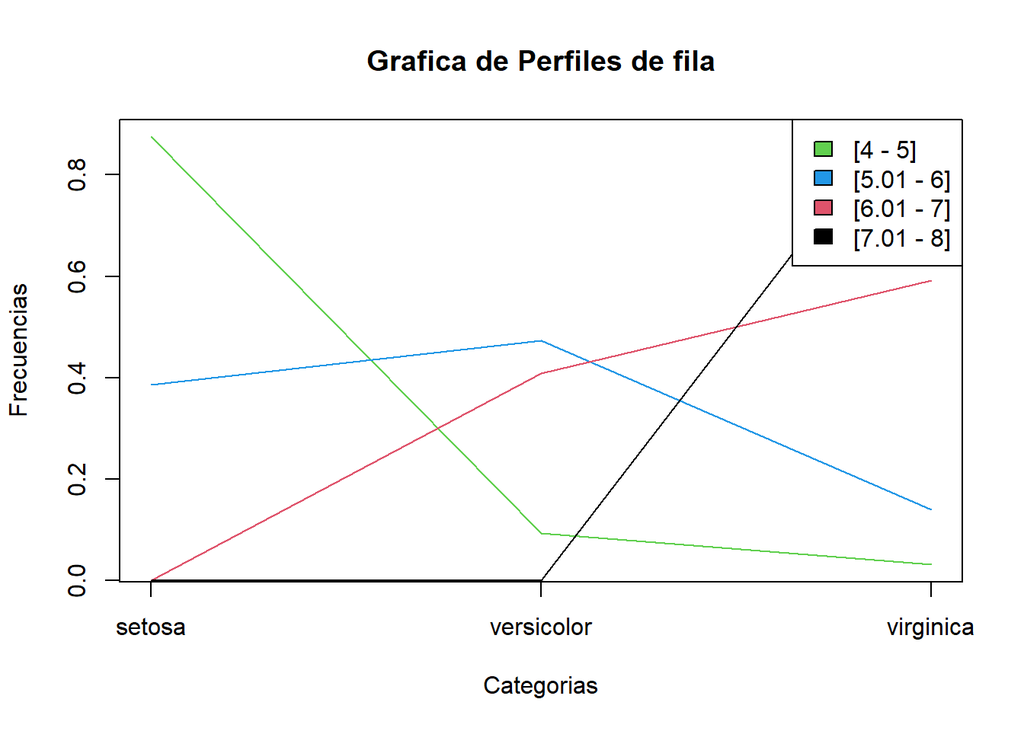

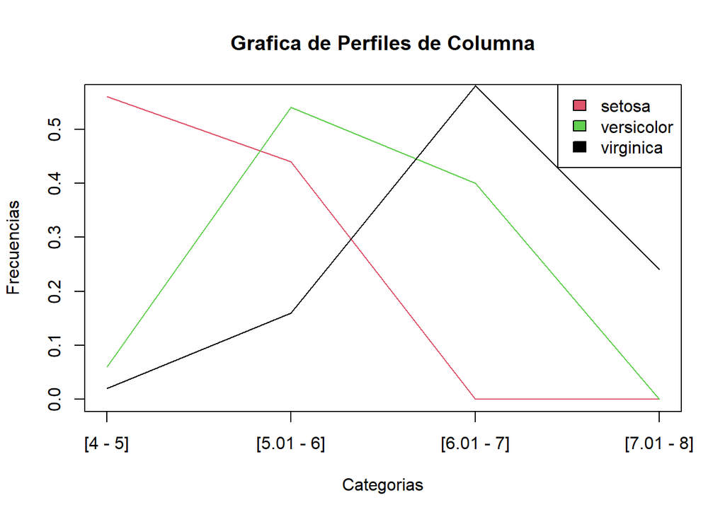

```
##
## ######### ANALISIS VARIABLE SPECIES CON LA VARIABLE Sepal.width  ############
##  --------Tabla de Contigencia---------
##              setosa versicolor virginica
##   [1 - 2]         0          1         0
##   [2.01 - 3]      8         41        33
##   [3.01 - 4]     39          8        17
##   [4.01 - 5]      3          0         0
##
##   -------Totales  marginales  de  fila--------
##    [1 - 2] [2.01 - 3] [3.01 - 4] [4.01 - 5]
##          1         82         64          3
##
##   -------Totales  marginales  de  columnas--------
##     setosa versicolor  virginica
##         50         50         50
##
##   -------Frecuencias  relativas -------
##                   setosa  versicolor   virginica
##   [1 - 2]    0.000000000 0.006666667 0.000000000
##   [2.01 - 3] 0.053333333 0.273333333 0.220000000
##   [3.01 - 4] 0.260000000 0.053333333 0.113333333
##   [4.01 - 5] 0.020000000 0.000000000 0.000000000
##
##   -------Perfiles  marginales  de  filas-------
##     [1 - 2]  [2.01 - 3]  [3.01 - 4]  [4.01 - 5]
## 0.006666667 0.546666667 0.426666667 0.020000000
##
##   -------Perfiles  marginales  de  columnas-------
##     setosa versicolor  virginica
##  0.3333333  0.3333333  0.3333333
##
##                  setosa versicolor  virginica
##   [1 - 2]    0.00000000 1.00000000 0.00000000
##   [2.01 - 3] 0.09756098 0.50000000 0.40243902
##   [3.01 - 4] 0.60937500 0.12500000 0.26562500
##   [4.01 - 5] 1.00000000 0.00000000 0.00000000
##
##              setosa versicolor virginica
##   [1 - 2]      0.00       0.02      0.00
```

[output cut: 12 more lines]

```
##  Hr= 1.161658
##   ------------ Entropía de columnas -------------
##  Hc= 1.584963
##   ------------ Entropía Conjunta ----------------
##  Hrc= 2.465505
##   ------- Entropía condicional de filas ---------
##  Hr_c= 0.8805423
##   ----- Entropía condicional de columnas --------
##  Hc_r= 1.303847
##   ------------- Información mutua ---------------
##  Irc= 0.2811154
##   ---------------- Phi - quadrado ---------------
##  Phi - quadrado= 0.3568445
##   ---------------- Chi - quadrado ---------------
##  chi - quadrado= 53.52668
```

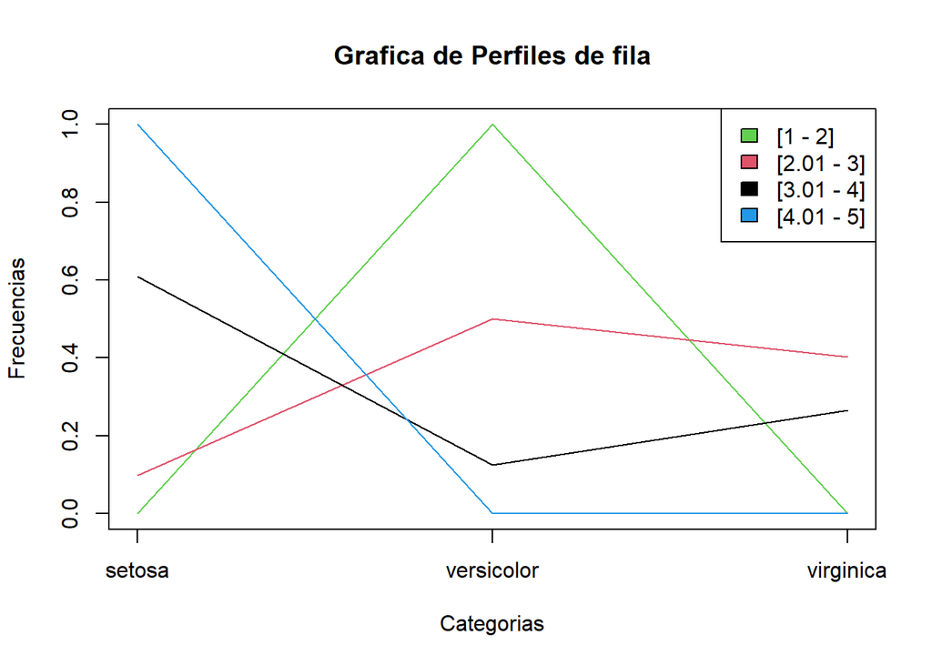

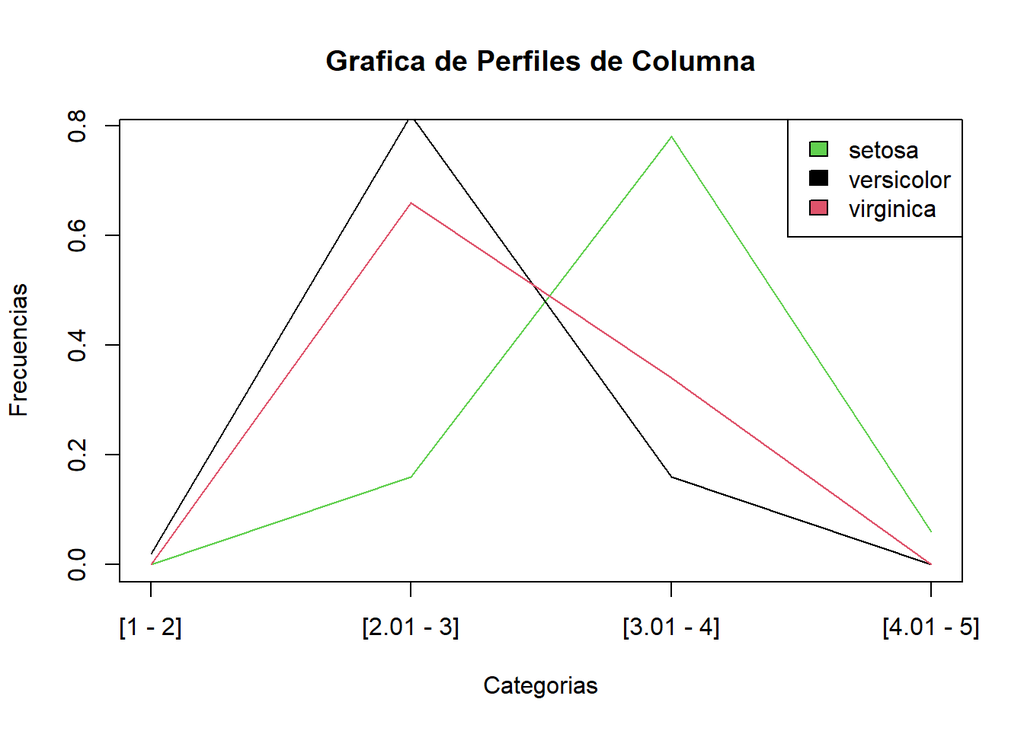

```
##
## ######### ANALISIS VARIABLE SPECIES CON LA VARIABLE Petal.length  ############
##  --------Tabla de Contigencia---------
##              setosa versicolor virginica
##   [0 - 1]         1          0         0
##   [1.01 - 2]     49          0         0
##   [2.01 - 3]      0          1         0
##   [3.01 - 4]      0         15         0
##   [4.01 - 5]      0         33         9
##   [5.01 - 6]      0          1        32
##   [6.01 - 7]      0          0         9
##
##   -------Totales  marginales  de  fila--------
##    [0 - 1] [1.01 - 2] [2.01 - 3] [3.01 - 4] [4.01 - 5] [5.01 - 6] [6.01 - 7]
##          1         49          1         15         42         33          9
##
##   -------Totales  marginales  de  columnas--------
##     setosa versicolor  virginica
##         50         50         50
##
##   -------Frecuencias  relativas -------
##                   setosa  versicolor   virginica
##   [0 - 1]    0.006666667 0.000000000 0.000000000
##   [1.01 - 2] 0.326666667 0.000000000 0.000000000
##   [2.01 - 3] 0.000000000 0.006666667 0.000000000
##   [3.01 - 4] 0.000000000 0.100000000 0.000000000
##   [4.01 - 5] 0.000000000 0.220000000 0.060000000
##   [5.01 - 6] 0.000000000 0.006666667 0.213333333
##   [6.01 - 7] 0.000000000 0.000000000 0.060000000
##
##   -------Perfiles  marginales  de  filas-------
##     [0 - 1]  [1.01 - 2]  [2.01 - 3]  [3.01 - 4]  [4.01 - 5]  [5.01 - 6]
## 0.006666667 0.326666667 0.006666667 0.100000000 0.280000000 0.220000000
##  [6.01 - 7]
## 0.060000000
##
##   -------Perfiles  marginales  de  columnas-------
##     setosa versicolor  virginica
##  0.3333333  0.3333333  0.3333333
##
```

[output cut: 29 more lines]

```
##  Hr= 2.19418
##   ------------ Entropía de columnas -------------
##  Hc= 1.584963
##   ------------ Entropía Conjunta ----------------
##  Hrc= 2.447167
##   ------- Entropía condicional de filas ---------
##  Hr_c= 0.8622042
##   ----- Entropía condicional de columnas --------
##  Hc_r= 0.2529867
##   ------------- Información mutua ---------------
##  Irc= 1.331976
##   ---------------- Phi - quadrado ---------------
##  Phi - quadrado= 1.678355
##   ---------------- Chi - quadrado ---------------
##  chi - quadrado= 251.7532
```

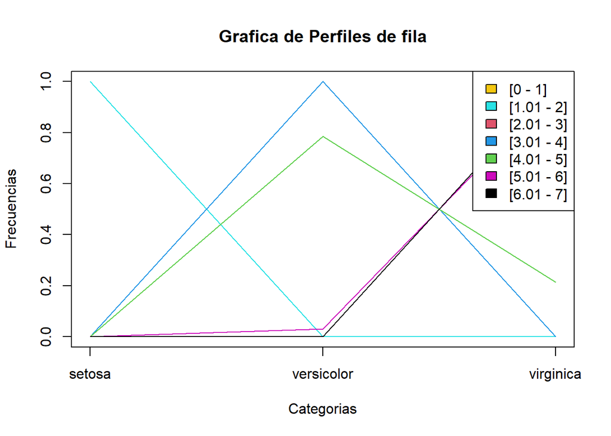

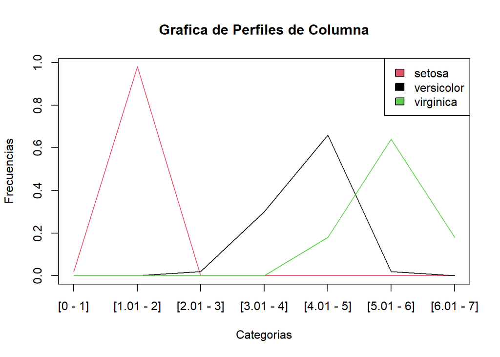

```
##
## ######### ANALISIS VARIABLE SPECIES CON LA VARIABLE Petal.width  ############
##  --------Tabla de Contigencia---------
##              setosa versicolor virginica
##   [0 - 1]        50          7         0
##   [1.01 - 2]      0         43        27
##   [2.01 - 3]      0          0        23
##
##   -------Totales  marginales  de  fila--------
##    [0 - 1] [1.01 - 2] [2.01 - 3]
##         57         70         23
##
##   -------Totales  marginales  de  columnas--------
##     setosa versicolor  virginica
##         50         50         50
##
##   -------Frecuencias  relativas -------
##                  setosa versicolor  virginica
##   [0 - 1]    0.33333333 0.04666667 0.00000000
##   [1.01 - 2] 0.00000000 0.28666667 0.18000000
##   [2.01 - 3] 0.00000000 0.00000000 0.15333333
##
##   -------Perfiles  marginales  de  filas-------
##    [0 - 1] [1.01 - 2] [2.01 - 3]
##  0.3800000  0.4666667  0.1533333
##
##   -------Perfiles  marginales  de  columnas-------
##     setosa versicolor  virginica
##  0.3333333  0.3333333  0.3333333
##
##                 setosa versicolor virginica
##   [0 - 1]    0.8771930  0.1228070 0.0000000
##   [1.01 - 2] 0.0000000  0.6142857 0.3857143
##   [2.01 - 3] 0.0000000  0.0000000 1.0000000
##
##              setosa versicolor virginica
##   [0 - 1]      1.00       0.14      0.00
##   [1.01 - 2]   0.00       0.86      0.54
##   [2.01 - 3]   0.00       0.00      0.46
##
##   -------Tabla  valores  esperados-------
##                  setosa versicolor  virginica
##   [0 - 1]    0.12666667 0.12666667 0.12666667
##   [1.01 - 2] 0.15555556 0.15555556 0.15555556
##   [2.01 - 3] 0.05111111 0.05111111 0.05111111
##
##   ------------ Entropía de filas ---------------
##  Hr= 1.458376
##   ------------ Entropía de columnas -------------
##  Hc= 1.584963
##   ------------ Entropía Conjunta ----------------
##  Hrc= 2.111502
##   ------- Entropía condicional de filas ---------
##  Hr_c= 0.5265391
##   ----- Entropía condicional de columnas --------
##  Hc_r= 0.653126
##   ------------- Información mutua ---------------
##  Irc= 0.9318365
##   ---------------- Phi - quadrado ---------------
##  Phi - quadrado= 1.090957
##   ---------------- Chi - quadrado ---------------
##  chi - quadrado= 163.6436
```

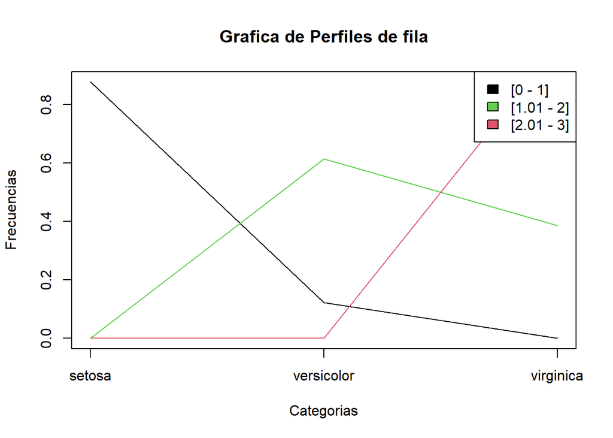

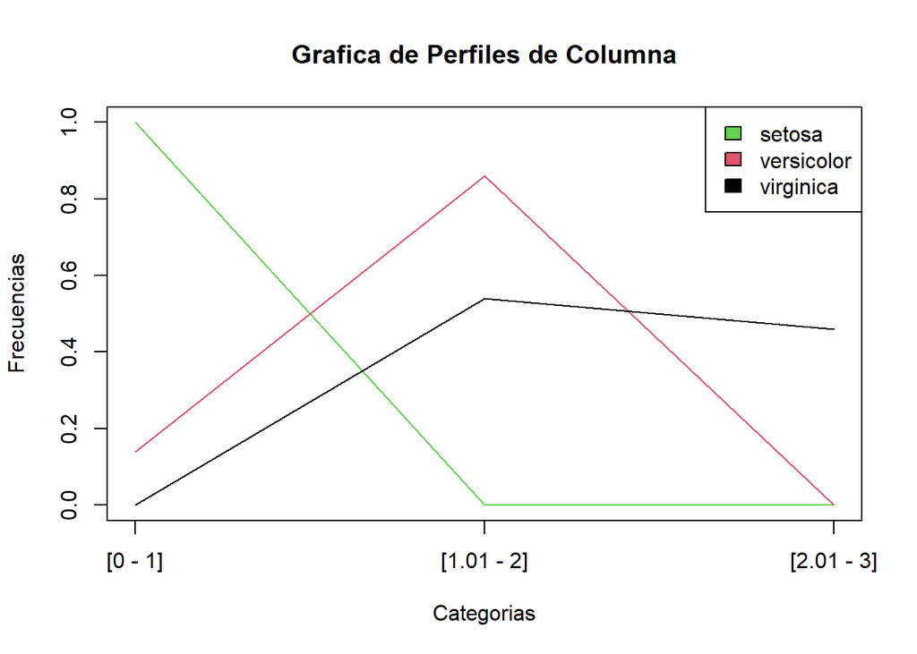

```r
#numero de variables cuantitativas mas una variable cualitativa
n<-ncol(iris)

#numero de variables categoricas de Species
m<-nlevels(iris$Species)

for(i in 1:(n-1)){
#for(i in 1:1){

cat("\n######### ANALISIS VARIABLE SPECIES CON LA VARIABLE",colnames(iris)[i]," ############")

#generacion de numeros para los intervalos
intervalos<-seq(from=ceiling(min(iris[i]))-1, to=ceiling(max(iris[i])),by=1)

# Generacion de etiquetas de los intervalos
for (z in 1:(length(intervalos)-1)){
  if(z==1){
     etiquetas<-c( paste0("[",format(intervalos[z],digits=2)," - ", round(intervalos[z+1],2),"]"))
    }
  else{
    etiquetas<-c(etiquetas,paste0("[",format(intervalos[z]+.01,digits=3)," - ", round(intervalos[z+1],2),"]"))
  }
}

iris[[i]]<-cut(iris[[i]], intervalos, labels = etiquetas)
tiris=table(iris[,i],iris[,n])
cat("\n --------Tabla de Contigencia---------")
print(tiris)

#Totales  marginales  de  fila
tr=margin.table(tiris,1)
cat("\n  -------Totales  marginales  de  fila--------")
print(tr)

#Totales  marginales  de  columnas
tc=margin.table(tiris,2)
cat("\n  -------Totales  marginales  de  columnas--------")
print(tc)

#Frecencias  relativas
firis=prop.table(tiris)
cat("\n  -------Frecuencias  relativas -------")
print(firis)

#Perfiles  marginales  de  fila
pr=margin.table(firis,1)
cat("\n  -------Perfiles  marginales  de  filas-------")
print(pr)

#Perfiles  marginales  de  columnas
pc=margin.table(firis,2)
cat("\n  -------Perfiles  marginales  de  columnas-------")
print(pc)

priris=prop.table(tiris,1)
print(priris)  #

pciris=prop.table(tiris,2)
print(pciris)  #

#Tabla  valores  esperados
exiris=pr%*%t(pc)
cat("\n  -------Tabla  valores  esperados-------")
print(exiris)

rbind  (tc,pc)
cbind  (tr,pr)

#ESTADISTICAS DE ENTROPIA
#Entropía de filas
Hr = - sum(pr*log(pr,2))
cat("\n  ------------ Entropía de filas ---------------\n")
cat("\tHr=",Hr)

#Entropía de columnas
Hc = - sum(pc*log(pc,2))
cat("\n  ------------ Entropía de columnas -------------\n")
cat("\tHc=",Hc)

#Entropía conjunta
Hrc = - sum(firis[!(firis==0)]*log(firis[!(firis==0)],2))
cat("\n  ------------ Entropía Conjunta ----------------\n")
cat("\tHrc=",Hrc)

#Entropía condicional de filas
Hr_c = Hrc - Hc
cat("\n  ------- Entropía condicional de filas ---------\n")
cat("\tHr_c=",Hr_c)

#Entropía condicional de columnas
Hc_r = Hrc - Hr
cat("\n  ----- Entropía condicional de columnas --------\n")
cat("\tHc_r=",Hc_r)

#Información mutua
Irc <- Hr + Hc - Hrc
cat("\n  ------------- Información mutua ---------------\n")
cat("\tIrc=",Irc)

#Phi - quadrado
phi2 = sum((firis-exiris)^2/exiris)
cat("\n  ---------------- Phi - quadrado ---------------\n")
cat("\tPhi - quadrado=",phi2)

# Chi- quadrado
chi2 = sum((firis-exiris)^2/exiris)*sum(tiris)
cat("\n  ---------------- Chi - quadrado ---------------\n")
cat("\tchi - quadrado=",chi2)

#PLOTEO DE PERFILES
#definicion de los colores de los perfiles de fila
color<-sample(1:(length(intervalos)-1),length(intervalos)-1,replace=FALSE)
plot(priris[1,],type="l",xaxt="n",xlab="Categorias",ylab="Frecuencias", main="Grafica de Perfiles de fila",col=color[1])
for(j in 2:length(color)){
  lines(1:m,priris[j,], col=color[j])
}
axis(1,at=1:m, labels = colnames(priris))
legend("topright",
       legend =rownames(priris),
       fill = color)
#definicion de los colores de los perfiles de columna
ll<-length(colnames(tiris))
color<-sample(1:ll,ll,replace=FALSE)
plot(pciris[,1],type="l",xaxt="n",xlab="Categorias",ylab="Frecuencias", main="Grafica de Perfiles de Columna",col=color[1])
for(j in 2:length(color)){
  lines(1:length(rownames(tiris)),pciris[,j], col=color[j])
}
axis(1,at=1:length(rownames(tiris)), labels = rownames(tiris))
legend("topright",
       legend =colnames(tiris),
       fill = color)
}
```